# Zooplankton CCA

Matt Brousil

August 21, 2019

Load data

```r
bigjoin <- readRDS(file = "../data/analysis_outputs/bigjoin.rds")
zoop <- read_excel("../data/NCCN_Zoops_Combined_For_FCA_May_2019.xlsx")
```

Prep data

```r
zoop[1487, "Taxa"] <- "ROT"
zoop[1487, "Taxonid"] <- 5

# Name matching table
match_sites <- readRDS(file = file.path("..",
                                        "data",
                                        "name_site_matches.rds"))

# Crosswalk common names for sites to site_codes
zoop <- left_join(x = zoop, y = match_sites,
                               by = c("Lake" = "old_name"))
```

Grab yearly environmental data…quick check

```r
bigjoin %>%
  filter(variable %in% c("secchi_value_m", "AirTemp", "BotTemp",
                         "MidTemp", "SurfTemp", "DO_top2m")) %>%
  select(park_code, site_code, event_year, start_date, ice_out_doy) %>%
  unique() %>%
  count(park_code, site_code, event_year, start_date) %>%
  arrange(desc(n))
```

```
## # A tibble: 257 x 5
##    park_code site_code event_year start_date     n
##    <chr>     <chr>          <dbl> <date>     <int>
##  1 MORA      LH14            2008 2008-08-26     1
##  2 MORA      LH14            2009 2009-08-10     1
##  3 MORA      LH14            2010 2010-08-11     1
##  4 MORA      LH14            2011 2011-08-30     1
##  5 MORA      LH14            2012 2012-08-20     1
##  6 MORA      LH14            2013 2013-08-13     1
##  7 MORA      LH14            2014 2014-08-18     1
##  8 MORA      LH14            2015 2015-08-10     1
##  9 MORA      LH14            2016 2016-08-15     1
## 10 MORA      LH14            2017 2017-08-14     1
## # ... with 247 more rows
```

```r
yearly_bigjoin <- bigjoin %>%
  filter(variable %in% c("secchi_value_m", "AirTemp", "BotTemp",
                         "MidTemp", "SurfTemp", "DO_top2m")) %>%
  select(park_code, site_code, event_year, variable, value,
         ice_out_doy) %>%
  unique()

head(yearly_bigjoin)
```

```
##   park_code site_code event_year variable     value ice_out_doy
## 1      OLYM       263       2007  AirTemp  8.517083         183
## 2      OLYM       263       2007  BotTemp  6.638333         183
## 3      OLYM       263       2007  MidTemp  6.892500         183
## 4      OLYM       263       2007 SurfTemp  8.782917         183
## 5      OLYM       623       2007  AirTemp 17.278750         195
## 6      OLYM       623       2007  BotTemp 15.639167         195
```

```r
head(zoop)
```

```
## # A tibble: 6 x 10
##   `Park&Year&Lake` Park   Year Lake   Code Density GenSp Taxa  Taxonid
##   <chr>            <chr> <dbl> <chr> <dbl>   <dbl> <chr> <chr>   <dbl>
## 1 OLYM&2016&Heath~ OLYM   2016 Heat~     0     0   No z~ <NA>       NA
## 2 MORA&2009&Allen  MORA   2009 Allen    12   359.  Daph~ CLAD        1
## 3 MORA&2010&Allen  MORA   2010 Allen    12   117.  Daph~ CLAD        1
## 4 MORA&2011&Allen  MORA   2011 Allen    12    28.6 Daph~ CLAD        1
## 5 MORA&2013&Allen  MORA   2013 Allen    12   306.  Daph~ CLAD        1
## 6 MORA&2014&Allen  MORA   2014 Allen    12    53.1 Daph~ CLAD        1
## # ... with 1 more variable: site_code <chr>
```

There’s 114 rows in the yearly_bigjoin that don’t match up with zoop data

```r
zoop_env <- inner_join(x = zoop, y = yearly_bigjoin,
          by = c("site_code",
                 "Year" = "event_year")) %>%
  spread(key = variable, value = value)
```

Double check that there’s not multiple measures/year (Spoiler: There are.)

```r
zoop_env %>%
  count(park_code, site_code, Year, GenSp) %>%
  arrange(desc(n))
```

```
## # A tibble: 1,711 x 5
##    park_code site_code  Year GenSp                      n
##    <chr>     <chr>     <dbl> <chr>                  <int>
##  1 MORA      LW32       2018 Conochilius unicornis      2
##  2 MORA      LW32       2018 Daphnia rosea              2
##  3 MORA      LW32       2018 Hesperodiaptomus kenai     2
##  4 MORA      LW32       2018 immature Daphnia           2
##  5 MORA      LW32       2018 Kellicottia longispina     2
##  6 MORA      LW32       2018 Keratella cochlearis       2
##  7 MORA      LW32       2018 Keratella serrulata        2
##  8 MORA      LW32       2018 Keratella taurocephala     2
##  9 MORA      LW32       2018 Microcyclops varicans      2
## 10 MORA      LW32       2018 Philodina sp               2
## # ... with 1,701 more rows
```

Deadwood has multiple samples per zoop species per year? I’m not clear as to why this is. Perhaps I’m missing something. Going to sum them up for now.

```r
zoop_env %>%
  filter(park_code == "MORA", site_code == "LW32", Year == "2018")
```

```
## # A tibble: 28 x 18
##    `Park&Year&Lake` Park   Year Lake   Code Density GenSp Taxa  Taxonid
##    <chr>            <chr> <dbl> <chr> <dbl>   <dbl> <chr> <chr>   <dbl>
##  1 MORA&2018&Deadw~ MORA   2018 Dead~    12   48.2  Daph~ CLAD        1
##  2 MORA&2018&Deadw~ MORA   2018 Dead~    12   19.3  Daph~ CLAD        1
##  3 MORA&2018&Deadw~ MORA   2018 Dead~    19   48.2  Poly~ CLAD        1
##  4 MORA&2018&Deadw~ MORA   2018 Dead~    19   77.2  Poly~ CLAD        1
##  5 MORA&2018&Deadw~ MORA   2018 Dead~    38   19.3  Micr~ COPE        2
##  6 MORA&2018&Deadw~ MORA   2018 Dead~    38    9.65 Micr~ COPE        2
##  7 MORA&2018&Deadw~ MORA   2018 Dead~    42    9.65 cala~ COPE        2
##  8 MORA&2018&Deadw~ MORA   2018 Dead~    43   19.3  Hesp~ COPE        2
##  9 MORA&2018&Deadw~ MORA   2018 Dead~    43    9.65 Hesp~ COPE        2
## 10 MORA&2018&Deadw~ MORA   2018 Dead~    51    9.65 naup~ COPE        2
## # ... with 18 more rows, and 9 more variables: site_code <chr>,
## #   park_code <chr>, ice_out_doy <int>, AirTemp <dbl>, BotTemp <dbl>,
## #   DO_top2m <dbl>, MidTemp <dbl>, secchi_value_m <dbl>, SurfTemp <dbl>
```

```r
zoop_sum <- zoop %>%
  group_by(Park, Year, Lake, site_code, Code, Taxa, Taxonid, GenSp) %>%
  summarise(density = sum(Density))

zoop_env_sum <- inner_join(x = zoop_sum, y = yearly_bigjoin,
                       by = c("site_code",
                              "Year" = "event_year")) %>%
  spread(key = variable, value = value)

# Looks good:
zoop_env_sum %>%
  count(park_code, site_code, Year, GenSp) %>%
  arrange(desc(n))
```

```
## # A tibble: 1,711 x 10
## # Groups:   Park, Year, Lake, site_code, Code, Taxa, Taxonid [1,711]
##    Park   Year Lake  site_code  Code Taxa  Taxonid park_code GenSp        n
##    <chr> <dbl> <chr> <chr>     <dbl> <chr>   <dbl> <chr>     <chr>    <int>
##  1 MORA   2009 Allen LN03         12 CLAD        1 MORA      Daphnia~     1
##  2 MORA   2009 Allen LN03         28 CLAD        1 MORA      Pleurox~     1
##  3 MORA   2009 Allen LN03         32 COPE        2 MORA      cyclopo~     1
##  4 MORA   2009 Allen LN03         38 COPE        2 MORA      Microcy~     1
##  5 MORA   2009 Allen LN03         42 COPE        2 MORA      calanoi~     1
##  6 MORA   2009 Allen LN03         44 COPE        2 MORA      Hespero~     1
##  7 MORA   2009 Allen LN03         45 COPE        2 MORA      Hespero~     1
##  8 MORA   2009 Allen LN03         50 COPE        2 MORA      small s~     1
##  9 MORA   2009 Allen LN03         51 COPE        2 MORA      nauplii      1
## 10 MORA   2009 Allen LN03         61 ROT         5 MORA      Conochi~     1
## # ... with 1,701 more rows
```

```r
# Variables in the dataset currently:
names(zoop_env_sum)
```

```
##  [1] "Park"           "Year"           "Lake"           "site_code"
##  [5] "Code"           "Taxa"           "Taxonid"        "GenSp"
##  [9] "density"        "park_code"      "ice_out_doy"    "AirTemp"
## [13] "BotTemp"        "DO_top2m"       "MidTemp"        "secchi_value_m"
## [17] "SurfTemp"
```

```r
# Let's pick a few predictors of interest:
zoop_env_select <- zoop_env_sum %>%
  select(Park:park_code, # the zoop + basic info,
         secchi_value_m, AirTemp, BotTemp,
         MidTemp, SurfTemp, DO_top2m)

# Now spread out the zoops to create cols for each taxa
zoop_env_sp <- spread(data = zoop_env_select,
                      key = GenSp, value = density)
```

Look at the dataset

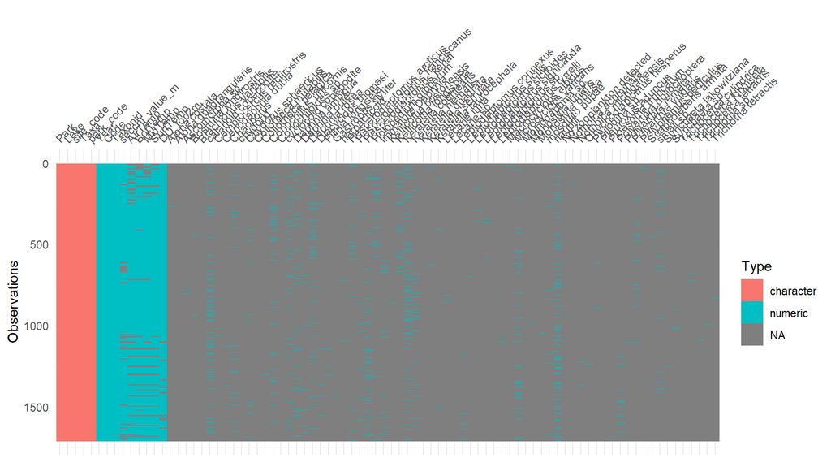

```r
vis_dat(zoop_env_sp)
```

Not sure this is the way to go…Looking at the absence of data in this df it’s clear that the species are fairly unique to specific places? Would still fill in the NAs with 0s, but still there’s a lot of zero data. Let’s try taxa instead. Going to backup a couple steps…

```r
zoop_sum_taxa <- zoop %>%
  # Dropping Code b/c it appears redundant with Taxa
  group_by(Park, Year, Lake, site_code, Taxa, Taxonid) %>%
  summarise(density = sum(Density))

zoop_env_sum_taxa <- inner_join(x = zoop_sum_taxa, y = yearly_bigjoin,
                           by = c("site_code",
                                  "Year" = "event_year")) %>%
  spread(key = variable, value = value)

# Looks good:
zoop_env_sum_taxa %>%
  count(park_code, site_code, Year, Taxa) %>%
  arrange(desc(n))
```

```
## # A tibble: 631 x 7
## # Groups:   Park, Year, Lake, site_code, Taxa [631]
##    Park   Year Lake     site_code Taxa  park_code     n
##    <chr> <dbl> <chr>    <chr>     <chr> <chr>     <int>
##  1 MORA   2009 Allen    LN03      CLAD  MORA          1
##  2 MORA   2009 Allen    LN03      COPE  MORA          1
##  3 MORA   2009 Allen    LN03      INS   MORA          1
##  4 MORA   2009 Allen    LN03      ROT   MORA          1
##  5 MORA   2009 Blue     LZ35      CLAD  MORA          1
##  6 MORA   2009 Blue     LZ35      COPE  MORA          1
##  7 MORA   2009 Blue     LZ35      ROT   MORA          1
##  8 MORA   2009 Deadwood LW32      CLAD  MORA          1
##  9 MORA   2009 Deadwood LW32      COPE  MORA          1
## 10 MORA   2009 Deadwood LW32      INS   MORA          1
## # ... with 621 more rows
```

```r
# Variables in the dataset currently:
names(zoop_env_sum_taxa)
```

```
##  [1] "Park"           "Year"           "Lake"           "site_code"
##  [5] "Taxa"           "Taxonid"        "density"        "park_code"
##  [9] "ice_out_doy"    "AirTemp"        "BotTemp"        "DO_top2m"
## [13] "MidTemp"        "secchi_value_m" "SurfTemp"
```

```r
# Let's pick a few predictors of interest:
zoop_env_taxa_select <- zoop_env_sum_taxa %>%
  select(Park:park_code, # the zoop + basic info,
         AirTemp, BotTemp, DO_top2m, MidTemp, secchi_value_m,
         SurfTemp,
         -Taxonid)

# Now spread out the zoops to create cols for each taxa
zoop_env_taxa_spread <- zoop_env_taxa_select %>%
  filter(!is.na(Taxa)) %>%
  spread(key = Taxa, value = density)
```

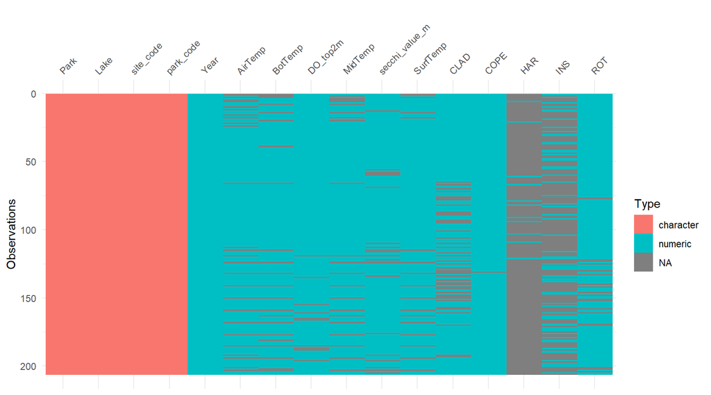

```r
vis_dat(zoop_env_taxa_spread)
```

CCA will only run if there are no NA values…I don’t think it makes sense to turn NA values for the env data into 0s. So, are there rows where all predictors aren’t NA?

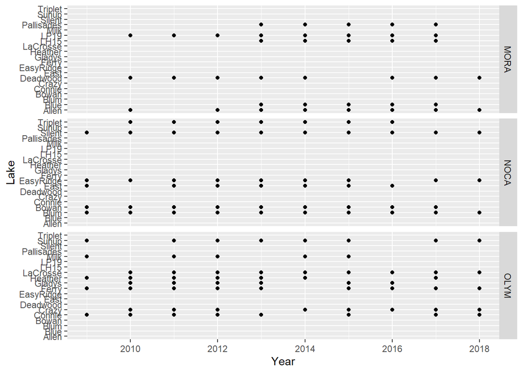

```r
zoop_env_taxa_select %>%
  filter_at(vars(AirTemp:SurfTemp), all_vars(!is.na(.))) %>%
  # What space and time spread to they cover?
  count(Park, Lake, Year) %>%
  ggplot() +
  geom_point(aes(x = Year, y = Lake)) +
  facet_grid(rows = vars(Park))
```

**How to account (at all?) account for the fact that not all lakes have identical timelines of zoop data, and some that do will probably have gaps in their environmental data?**

```r
# Save a new version of the dataset that has only data with no predictor NAs
zoop_env_taxa_no_na <- zoop_env_taxa_select %>%
  filter_at(vars(AirTemp:SurfTemp), all_vars(!is.na(.)))

zoop_env_taxa_no_na_spread <- zoop_env_taxa_no_na %>%
    spread(key = Taxa, value = density)

cca_taxa_data <- zoop_env_taxa_no_na_spread %>%
  data.frame() %>%
  select(CLAD:ROT) %>%
  # Replace NAs with 0s
  map_df(.x = .,  ~ replace_na(data = ., replace = 0))

cca_env_data <- zoop_env_taxa_no_na_spread %>%
  data.frame() %>%
  select(AirTemp:SurfTemp)

zoop_cca <- cca(X = as.matrix(cca_taxa_data),
                Y = as.matrix(cca_env_data))
```

The plot looks suspect to me:

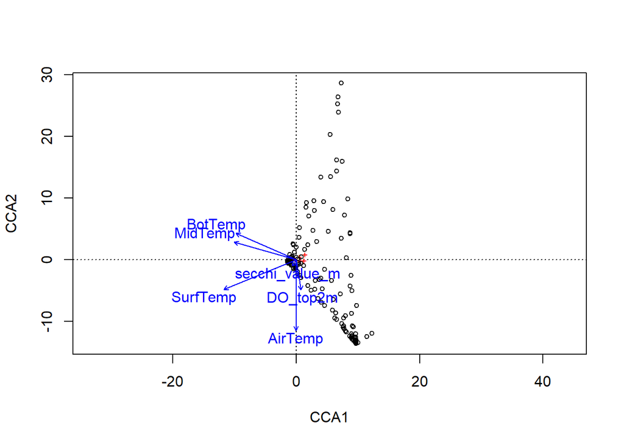

```r
ordiplot(zoop_cca)
```

Notably, an NMDS will now **sometimes** run with these reduced data…Though I don’t think that they’ve been reduced in a way that’s justifiable for NMDS? It runs also if we use 3 dimensions instead of 2.

```r
zoop_nmds_alt <- metaMDS(comm = cca_taxa_data, try = 100)
```

```r
zoop_nmds_alt
```

```
##
## Call:
## metaMDS(comm = cca_taxa_data, try = 100)
##
## global Multidimensional Scaling using monoMDS
##
## Data:     wisconsin(sqrt(cca_taxa_data))
## Distance: bray
##
## Dimensions: 2
## Stress:     0.1556893
## Stress type 1, weak ties
## Two convergent solutions found after 100 tries
## Scaling: centring, PC rotation, halfchange scaling
## Species: expanded scores based on 'wisconsin(sqrt(cca_taxa_data))'
```

```r
zoop_nmds_3 <- metaMDS(cca_taxa_data, k = 3)
```

```r
zoop_nmds_3
```

```
##
## Call:
## metaMDS(comm = cca_taxa_data, k = 3)
##
## global Multidimensional Scaling using monoMDS
##
## Data:     wisconsin(sqrt(cca_taxa_data))
## Distance: bray
##
## Dimensions: 3
## Stress:     0.07317614
## Stress type 1, weak ties
## Two convergent solutions found after 20 tries
## Scaling: centring, PC rotation, halfchange scaling
## Species: expanded scores based on 'wisconsin(sqrt(cca_taxa_data))'
```

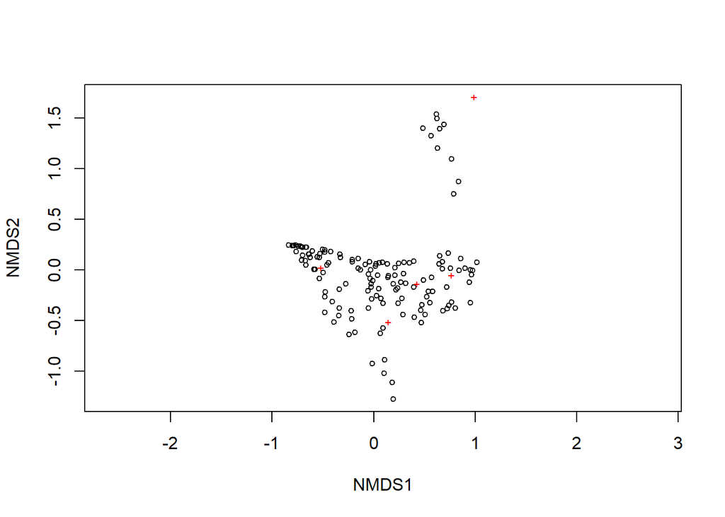

```r
ordiplot(zoop_nmds_3)
```

Per MM, Distance-based redundancy analysis. Using example code from: [link](https://sites.ualberta.ca/~ahamann/teaching/renr690/Lab9b.pdf)

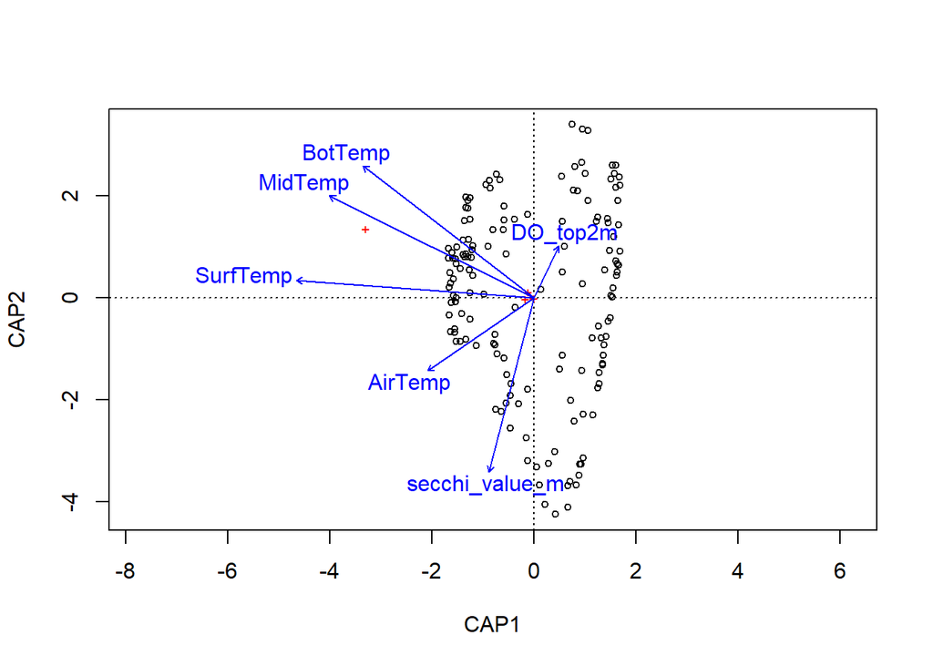

```r
dbrda <- capscale(formula = cca_taxa_data ~ DO_top2m + SurfTemp + MidTemp +
                    BotTemp + AirTemp + secchi_value_m, data = cca_env_data,
                  distance = "bray")

ordiplot(dbrda)
```

```r
anova(dbrda)
```

```
## Permutation test for capscale under reduced model
## Permutation: free
## Number of permutations: 999
##
## Model: capscale(formula = cca_taxa_data ~ DO_top2m + SurfTemp + MidTemp + BotTemp + AirTemp + secchi_value_m, data = cca_env_data, distance = "bray")
##           Df SumOfSqs      F Pr(>F)
## Model      6    8.358 4.2267  0.001 ***
## Residual 144   47.460
## ---
## Signif. codes:  0 '***' 0.001 '**' 0.01 '*' 0.05 '.' 0.1 ' ' 1
```

```r
anova(dbrda, by = "axis", perm.max = 500)
```

```
## Permutation test for capscale under reduced model
## Forward tests for axes
## Permutation: free
## Number of permutations: 999
##
## Model: capscale(formula = cca_taxa_data ~ DO_top2m + SurfTemp + MidTemp + BotTemp + AirTemp + secchi_value_m, data = cca_env_data, distance = "bray")
##           Df SumOfSqs       F Pr(>F)
## CAP1       1    6.351 19.2702  0.001 ***
## CAP2       1    1.083  3.2850  0.115
## CAP3       1    0.432  1.3093  0.884
## CAP4       1    0.345  1.0460  0.900
## CAP5       1    0.101  0.3051  1.000
## CAP6       1    0.048  0.1445  1.000
## Residual 144   47.460
## ---
## Signif. codes:  0 '***' 0.001 '**' 0.01 '*' 0.05 '.' 0.1 ' ' 1
```

```r
anova(dbrda, by = "terms", permu = 200)
```

```
## Permutation test for capscale under reduced model
## Terms added sequentially (first to last)
## Permutation: free
## Number of permutations: 999
##
## Model: capscale(formula = cca_taxa_data ~ DO_top2m + SurfTemp + MidTemp + BotTemp + AirTemp + secchi_value_m, data = cca_env_data, distance = "bray")
##                 Df SumOfSqs       F Pr(>F)
## DO_top2m         1    0.243  0.7380  0.721
## SurfTemp         1    5.759 17.4724  0.001 ***
## MidTemp          1    0.655  1.9889  0.049 *
## BotTemp          1    0.584  1.7706  0.084 .
## AirTemp          1    0.449  1.3626  0.190
## secchi_value_m   1    0.668  2.0277  0.049 *
## Residual       144   47.460
## ---
## Signif. codes:  0 '***' 0.001 '**' 0.01 '*' 0.05 '.' 0.1 ' ' 1
```

How to evaluate?

Take a look at COPE:ROT CLAD, COPE, ROT are 3 major groups

## Look at environmental variables ~ watershed characteristics now.

```r
physio <- read_excel(path = "../data/analysis_outputs/study-site-tables.xlsx",
                     sheet = 1)

physio <- left_join(x = physio, y = match_sites,
                               by = c("Lake" = "old_name"))
```

```r
# Grab yearly data...quick check
bigjoin %>%
  filter(variable %in% c("AirTemp", "BotTemp", "MidTemp", "SurfTemp",
                         "Chlorophyll", "ice_in_doy", "ice_out_doy")) %>%
  select(park_code, site_code, event_year, start_date, ice_out_doy) %>%
  unique() %>%
  count(park_code, site_code, event_year, start_date) %>%
  arrange(desc(n))
```

```
## # A tibble: 384 x 5
##    park_code site_code event_year start_date     n
##    <chr>     <chr>          <dbl> <date>     <int>
##  1 MORA      LH14            2008 2008-08-26     1
##  2 MORA      LH14            2009 2009-08-10     1
##  3 MORA      LH14            2010 2010-08-11     1
##  4 MORA      LH14            2010 NA             1
##  5 MORA      LH14            2011 2011-08-30     1
##  6 MORA      LH14            2012 2012-08-20     1
##  7 MORA      LH14            2013 2013-08-13     1
##  8 MORA      LH14            2013 NA             1
##  9 MORA      LH14            2014 2014-08-18     1
## 10 MORA      LH14            2014 NA             1
## # ... with 374 more rows
```

```r
yearly_bigjoin_wshd <- bigjoin %>%
  filter(variable %in% c("AirTemp", "BotTemp", "MidTemp", "SurfTemp",
                         "Chlorophyll", "ice_in_doy", "ice_out_doy",
                         "pH_top2m", "pH_below2m")) %>%
  select(park_code, site_code, event_year, variable, value) %>%
  unique()

head(yearly_bigjoin_wshd)
```

```
##   park_code site_code event_year    variable value
## 1      MORA      LH14       2008 Chlorophyll 0.128
## 2      MORA      LH14       2009 Chlorophyll 0.257
## 3      MORA      LH14       2010 Chlorophyll 0.033
## 4      MORA      LH14       2011 Chlorophyll 0.162
## 5      MORA      LH14       2012 Chlorophyll 0.159
## 6      MORA      LH14       2013 Chlorophyll 0.164
```

```r
env_phys_wshd <- left_join(x = yearly_bigjoin_wshd,
                           y = physio,
                           by = c("site_code")) %>%
  spread(key = variable, value = value)
```

The ice_in/ice_out data are spotty as seen previously

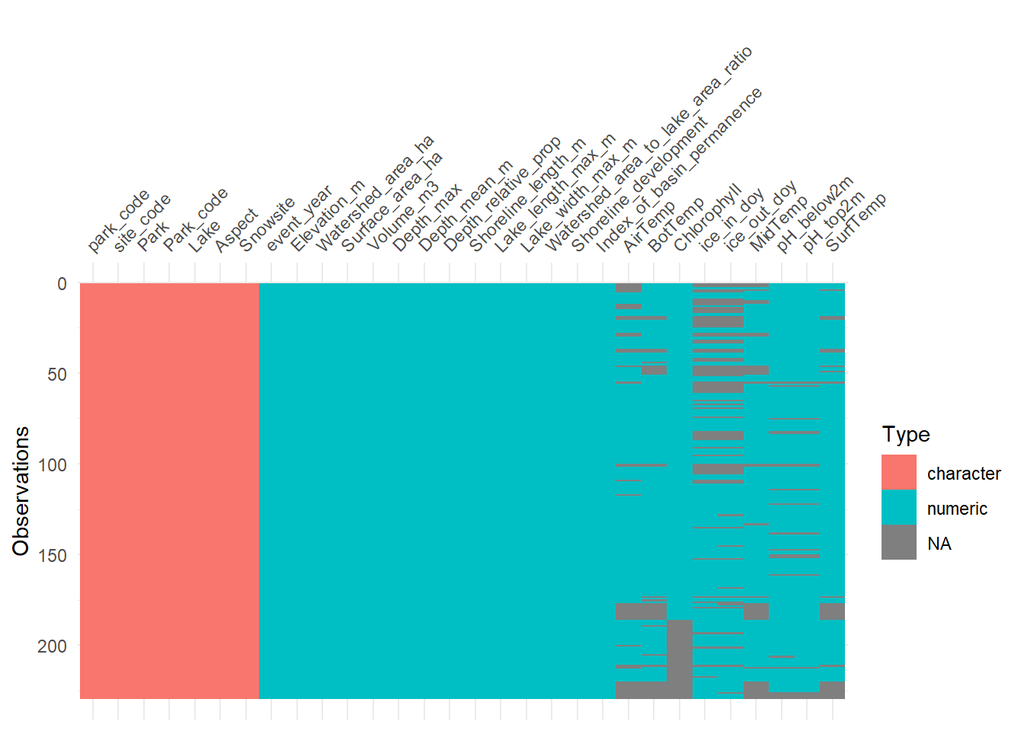

```r
vis_dat(env_phys_wshd)
```

How many rows if we remove NAs and the ice variables?

```r
env_phys_wshd %>%
  select(-contains("ice")) %>%
  filter_all(all_vars(!is.na(.))) %>%
  nrow()
```

```
## [1] 135
```

135 rows

How many rows if we remove NAs but keep ice variables?

```r
env_phys_wshd %>%
  filter_all(all_vars(!is.na(.))) %>%
  nrow()
```

```
## [1] 99
```

99 rows

Go forth with the ice data removed

```r
env_phys_wshd <- env_phys_wshd %>%
  select(-contains("ice")) %>%
  filter_all(all_vars(!is.na(.)))
```

Split into the two components for following analyses

```r
cca_env_wshd <- env_phys_wshd %>%
  select(AirTemp:SurfTemp)

cca_wsh_vars <- env_phys_wshd %>%
  select(Elevation_m, Aspect, Watershed_area_ha,
         Watershed_area_to_lake_area_ratio, Surface_area_ha, Volume_m3,
         Depth_mean_m)
```

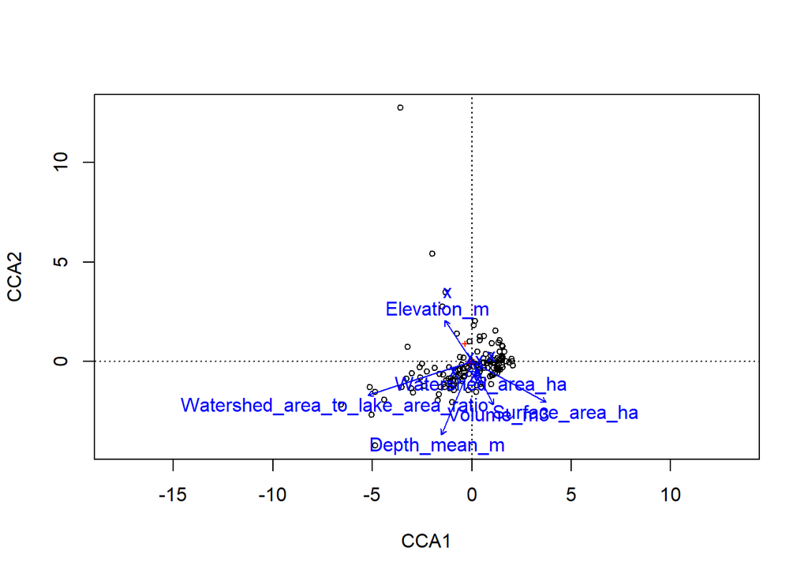

```r
watershed_cca <- cca(formula = cca_env_wshd ~ Elevation_m + Aspect +
                       Watershed_area_ha + Watershed_area_to_lake_area_ratio +
                       Surface_area_ha + Volume_m3 + Depth_mean_m,
                     data = cca_wsh_vars)

ordiplot(watershed_cca)
```

```r
anova.cca(watershed_cca)
```

```
## Permutation test for cca under reduced model
## Permutation: free
## Number of permutations: 999
##
## Model: cca(formula = cca_env_wshd ~ Elevation_m + Aspect + Watershed_area_ha + Watershed_area_to_lake_area_ratio + Surface_area_ha + Volume_m3 + Depth_mean_m, data = cca_wsh_vars)
##           Df ChiSquare      F Pr(>F)
## Model     13  0.020451 4.0222  0.001 ***
## Residual 121  0.047325
## ---
## Signif. codes:  0 '***' 0.001 '**' 0.01 '*' 0.05 '.' 0.1 ' ' 1
```

```r
anova.cca(watershed_cca, by = "axis", perm.max = 500)
```

```
## Permutation test for cca under reduced model
## Forward tests for axes
## Permutation: free
## Number of permutations: 999
##
## Model: cca(formula = cca_env_wshd ~ Elevation_m + Aspect + Watershed_area_ha + Watershed_area_to_lake_area_ratio + Surface_area_ha + Volume_m3 + Depth_mean_m, data = cca_wsh_vars)
##           Df ChiSquare       F Pr(>F)
## CCA1       1  0.009961 26.9406  0.001 ***
## CCA2       1  0.006686 18.0834  0.001 ***
## CCA3       1  0.002869  7.7600  0.155
## CCA4       1  0.000747  2.0205  0.998
## CCA5       1  0.000182  0.4912  1.000
## CCA6       1  0.000007  0.0182  1.000
## Residual 128  0.047325
## ---
## Signif. codes:  0 '***' 0.001 '**' 0.01 '*' 0.05 '.' 0.1 ' ' 1
```

```r
anova.cca(watershed_cca, by = "terms", permu = 200)
```

```
## Permutation test for cca under reduced model
## Terms added sequentially (first to last)
## Permutation: free
## Number of permutations: 999
##
## Model: cca(formula = cca_env_wshd ~ Elevation_m + Aspect + Watershed_area_ha + Watershed_area_to_lake_area_ratio + Surface_area_ha + Volume_m3 + Depth_mean_m, data = cca_wsh_vars)
##                                    Df ChiSquare      F Pr(>F)
## Elevation_m                         1  0.001250 3.1966  0.008 **
## Aspect                              7  0.012178 4.4480  0.001 ***
## Watershed_area_ha                   1  0.000502 1.2839  0.225
## Watershed_area_to_lake_area_ratio   1  0.003208 8.2023  0.001 ***
## Surface_area_ha                     1  0.000848 2.1687  0.092 .
## Volume_m3                           1  0.002037 5.2091  0.002 **
## Depth_mean_m                        1  0.000427 1.0926  0.347
## Residual                          121  0.047325
## ---
## Signif. codes:  0 '***' 0.001 '**' 0.01 '*' 0.05 '.' 0.1 ' ' 1
```

Reduced CCA

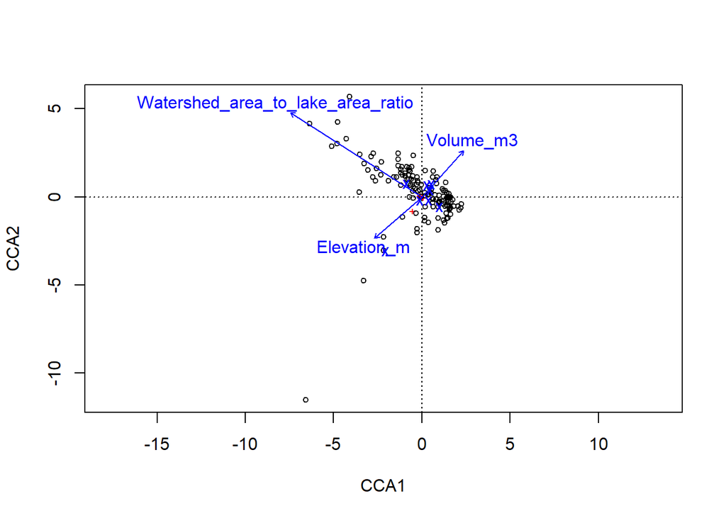

```r
watershed_cca_2 <- cca(formula = cca_env_wshd ~ Elevation_m + Aspect +
                       Watershed_area_to_lake_area_ratio + Volume_m3,
                     data = cca_wsh_vars)

ordiplot(watershed_cca_2)
```

```r
anova.cca(watershed_cca_2)
```

```
## Permutation test for cca under reduced model
## Permutation: free
## Number of permutations: 999
##
## Model: cca(formula = cca_env_wshd ~ Elevation_m + Aspect + Watershed_area_to_lake_area_ratio + Volume_m3, data = cca_wsh_vars)
##           Df ChiSquare      F Pr(>F)
## Model     10  0.017795 4.4147  0.001 ***
## Residual 124  0.049982
## ---
## Signif. codes:  0 '***' 0.001 '**' 0.01 '*' 0.05 '.' 0.1 ' ' 1
```

```r
anova.cca(watershed_cca_2, by = "axis", perm.max = 500)
```

```
## Permutation test for cca under reduced model
## Forward tests for axes
## Permutation: free
## Number of permutations: 999
##
## Model: cca(formula = cca_env_wshd ~ Elevation_m + Aspect + Watershed_area_to_lake_area_ratio + Volume_m3, data = cca_wsh_vars)
##           Df ChiSquare       F Pr(>F)
## CCA1       1  0.008316 21.2967  0.001 ***
## CCA2       1  0.006398 16.3852  0.001 ***
## CCA3       1  0.002333  5.9736  0.153
## CCA4       1  0.000603  1.5444  0.997
## CCA5       1  0.000139  0.3557  1.000
## CCA6       1  0.000006  0.0159  1.000
## Residual 128  0.049982
## ---
## Signif. codes:  0 '***' 0.001 '**' 0.01 '*' 0.05 '.' 0.1 ' ' 1
```

```r
anova.cca(watershed_cca_2, by = "terms", permu = 200)
```

```
## Permutation test for cca under reduced model
## Terms added sequentially (first to last)
## Permutation: free
## Number of permutations: 999
##
## Model: cca(formula = cca_env_wshd ~ Elevation_m + Aspect + Watershed_area_to_lake_area_ratio + Volume_m3, data = cca_wsh_vars)
##                                    Df ChiSquare      F Pr(>F)
## Elevation_m                         1  0.001250 3.1017  0.020 *
## Aspect                              7  0.012178 4.3160  0.001 ***
## Watershed_area_to_lake_area_ratio   1  0.003565 8.8433  0.001 ***
## Volume_m3                           1  0.000802 1.9902  0.124
## Residual                          124  0.049982
## ---
## Signif. codes:  0 '***' 0.001 '**' 0.01 '*' 0.05 '.' 0.1 ' ' 1
```

Is it an issue including a categorical variable here? Can’t specify Bray distance while doing so…

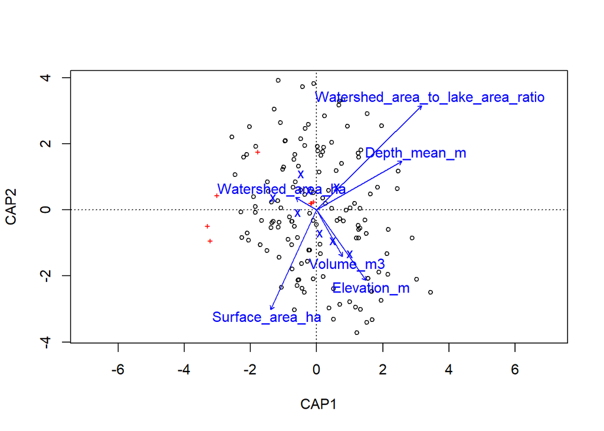

```r
dbrda_wshd <- capscale(formula = cca_env_wshd ~ Elevation_m + Aspect +
                       Watershed_area_ha + Watershed_area_to_lake_area_ratio +
                       Surface_area_ha + Volume_m3 + Depth_mean_m,
                     data = cca_wsh_vars)

ordiplot(dbrda_wshd)
```

```r
anova(dbrda_wshd)
```

```
## Permutation test for capscale under reduced model
## Permutation: free
## Number of permutations: 999
##
## Model: capscale(formula = cca_env_wshd ~ Elevation_m + Aspect + Watershed_area_ha + Watershed_area_to_lake_area_ratio + Surface_area_ha + Volume_m3 + Depth_mean_m, data = cca_wsh_vars)
##           Df Variance      F Pr(>F)
## Model     13   30.336 5.9801  0.001 ***
## Residual 121   47.217
## ---
## Signif. codes:  0 '***' 0.001 '**' 0.01 '*' 0.05 '.' 0.1 ' ' 1
```

```r
anova(dbrda_wshd, by = "axis", perm.max = 500)
```

```
## Permutation test for capscale under reduced model
## Forward tests for axes
## Permutation: free
## Number of permutations: 999
##
## Model: capscale(formula = cca_env_wshd ~ Elevation_m + Aspect + Watershed_area_ha + Watershed_area_to_lake_area_ratio + Surface_area_ha + Volume_m3 + Depth_mean_m, data = cca_wsh_vars)
##           Df Variance       F Pr(>F)
## CAP1       1   25.423 68.3806  0.001 ***
## CAP2       1    3.487  9.3791  0.366
## CAP3       1    0.654  1.7597  1.000
## CAP4       1    0.543  1.4618  1.000
## CAP5       1    0.132  0.3552  1.000
## CAP6       1    0.094  0.2530  1.000
## CAP7       1    0.003  0.0068  1.000
## Residual 127   47.217
## ---
## Signif. codes:  0 '***' 0.001 '**' 0.01 '*' 0.05 '.' 0.1 ' ' 1
```

```r
anova(dbrda_wshd, by = "terms", permu = 200)
```

```
## Permutation test for capscale under reduced model
## Terms added sequentially (first to last)
## Permutation: free
## Number of permutations: 999
##
## Model: capscale(formula = cca_env_wshd ~ Elevation_m + Aspect + Watershed_area_ha + Watershed_area_to_lake_area_ratio + Surface_area_ha + Volume_m3 + Depth_mean_m, data = cca_wsh_vars)
##                                    Df Variance       F Pr(>F)
## Elevation_m                         1    1.009  2.5852  0.078 .
## Aspect                              7   17.010  6.2273  0.001 ***
## Watershed_area_ha                   1    0.894  2.2920  0.099 .
## Watershed_area_to_lake_area_ratio   1    4.221 10.8173  0.001 ***
## Surface_area_ha                     1    3.179  8.1467  0.003 **
## Volume_m3                           1    3.644  9.3380  0.003 **
## Depth_mean_m                        1    0.379  0.9710  0.395
## Residual                          121   47.217
## ---
## Signif. codes:  0 '***' 0.001 '**' 0.01 '*' 0.05 '.' 0.1 ' ' 1
```